# Metody oparte o sąsiedztwo

## Wstęp

Laboratorium składa się z 2 części:

1. kNN w uczeniu nadzorowanym
2. Wyszukiwanie

W pierwszej części użyjemy standardowych bibliotek oraz dodatkowo `pynndescent`, implementującego algorytm NN-Descent do approximate nearest neighbors (ANN).

W drugiej części natomiast do wektoryzacji obiektów użyjemy stosu do uczenia głębokiego opartego o PyTorcha i Sentence Transformers - biblioteki implementującej transformery do uczenia nienadzorowanego i wyszukiwania.

```python
# !pip3 install torch torchvision torchaudio
```

```python
import matplotlib.pyplot as plt
import numpy as np
import pandas as pd
```

## Zbiór danych - klasyfikacja danych numerycznych

Wykorzystamy zbiór danych [Codon usage](https://archive.ics.uci.edu/ml/datasets/Codon+usage) z dziedziny bioinformatyki. Został on zaprezentowany w artykule:

Hallee, Logan, and Bohdan B. Khomtchouk. *"Machine learning classifiers predict key genomic and evolutionary traits across the kingdoms of life."* Scientific Reports 13.1 (2023): 2088. [link](https://www.nature.com/articles/s41598-023-28965-7)

Autorzy wykonywali na nim wiele analiz, ale nas interesuje podstawowa - przewidywanie, z jakiego królestwa (kingdom) pochodzi komórka, na podstawie rozkładu kodonów w jej sekwencjonowanym RNA. Analiza DNA oraz RNA jest podstawowym zadaniem bioinformatyki. Kodony (codons) to trójki nukleotydów, np. UGC, i większość zapisuje pewien aminokwas (z wyjątkiem trzech kodonów stopu), który jest wykorzystywany w syntezie białek.

Problem jest taki, że w praktyce trzeba sekwencjonować DNA/RNA z wielu komórek, więc trzeba je namnożyć w laboratorium. Niestety nie da się uzyskać idealnej czystości, i zawsze jest szansa, że próbka zostanie zanieczyszczona, np. bakteriami. Wtedy oprócz interesujących nas komórek (np. zwierzęcych) otrzymamy inne, których trzeba się pozbyć przed dalszą analizą. Tutaj właśnie wchodzi ML - dokonamy klasyfikacji, z jakiego królestwa (a właściwie domeny) pochodzi kod RNA, żeby pomóc w takich sytuacjach.

Dla uproszczenia, autorzy, zamiast klasyfikować królestwo, klasyfikują domenę organizmu. Są to jednostki o poziom wyżej w systematyce taksonomicznej. Do tego dokładamy wirusy i bakteriofagi. Mamy zatem klasy:

1. Archaea ([archeony](https://pl.wikipedia.org/wiki/Archeony)) - drobne jednokomórkowce, źródło ważnych [enzymów stosowanych w biologii molekularnej](https://en.wikipedia.org/wiki/Archaea#Significance_in_technology_and_industry)
2. Bacteria ([bakterie](https://pl.wikipedia.org/wiki/Bakterie))
3. Eukariota ([eukarionty](https://pl.wikipedia.org/wiki/Eukarionty)) - między innymi ludzie
4. Viruses ([wirusy](https://pl.wikipedia.org/wiki/Wirusy)) - nie są organizmami żywymi, więc nie są częścią typowej taksonomii, ale są ważne w badaniach mikrobiologicznych
5. Bacteriophages ([bakteriofagi](https://pl.wikipedia.org/wiki/Bakteriofag)) - rodzaj wirusów atakujących tylko bakterie, używane m.in. [w badaniach nad mikrobiomem jelitowym](https://kids.frontiersin.org/articles/10.3389/frym.2019.00146)

Szczegółowy opis zbioru znajduje się [na stronie UCI](https://archive.ics.uci.edu/ml/datasets/Codon+usage). W skrócie:

1. `Kingdom` - królestwo, z którego pochodzi komórka. Podział jest tutaj dość szczegółowy, ale organizmy te można pogrupować w praktyce na bakterie (bacteria), wirusy (viruses) i eukarionty (eukariota).
2. `DNAtype` - używana w innych analizach w artykule.
3. `SpeciesID` - numer gatunku.
4. `Ncodons` - liczba kodonów zmierzona dla danej komórki.
5. `SpeciesName` - nazwa gatunku.

Dalsze kolumny to znormalizowany ułamek kodonów poszczególnych typów w RNA danej komórki. W związku z tym, że dane są już znormalizowane, nie ma potrzeby ich skalowania.

```python
df = pd.read_csv("codon_usage.csv")
df
```

```
C:\Users\basia\AppData\Local\Temp\ipykernel_22828\2756931748.py:1: DtypeWarning: Columns (5,6) have mixed types. Specify dtype option on import or set low_memory=False.
  df = pd.read_csv("codon_usage.csv")
```

|  | Kingdom | DNAtype | SpeciesID | Ncodons | SpeciesName | UUU | UUC | UUA | UUG | CUU | ... | CGG | AGA | AGG | GAU | GAC | GAA | GAG | UAA | UAG | UGA |
| --- | --- | --- | --- | --- | --- | --- | --- | --- | --- | --- | --- | --- | --- | --- | --- | --- | --- | --- | --- | --- | --- |
| 0 | vrl | 0 | 100217 | 1995 | Epizootic haematopoietic necrosis virus | 0.01654 | 0.01203 | 0.00050 | 0.00351 | 0.01203 | ... | 0.00451 | 0.01303 | 0.03559 | 0.01003 | 0.04612 | 0.01203 | 0.04361 | 0.00251 | 0.00050 | 0.00000 |
| 1 | vrl | 0 | 100220 | 1474 | Bohle iridovirus | 0.02714 | 0.01357 | 0.00068 | 0.00678 | 0.00407 | ... | 0.00136 | 0.01696 | 0.03596 | 0.01221 | 0.04545 | 0.01560 | 0.04410 | 0.00271 | 0.00068 | 0.00000 |
| 2 | vrl | 0 | 100755 | 4862 | Sweet potato leaf curl virus | 0.01974 | 0.0218 | 0.01357 | 0.01543 | 0.00782 | ... | 0.00596 | 0.01974 | 0.02489 | 0.03126 | 0.02036 | 0.02242 | 0.02468 | 0.00391 | 0.00000 | 0.00144 |
| 3 | vrl | 0 | 100880 | 1915 | Northern cereal mosaic virus | 0.01775 | 0.02245 | 0.01619 | 0.00992 | 0.01567 | ... | 0.00366 | 0.01410 | 0.01671 | 0.03760 | 0.01932 | 0.03029 | 0.03446 | 0.00261 | 0.00157 | 0.00000 |
| 4 | vrl | 0 | 100887 | 22831 | Soil-borne cereal mosaic virus | 0.02816 | 0.01371 | 0.00767 | 0.03679 | 0.01380 | ... | 0.00604 | 0.01494 | 0.01734 | 0.04148 | 0.02483 | 0.03359 | 0.03679 | 0.00000 | 0.00044 | 0.00131 |
| ... | ... | ... | ... | ... | ... | ... | ... | ... | ... | ... | ... | ... | ... | ... | ... | ... | ... | ... | ... | ... | ... |
| 13023 | pri | 0 | 9601 | 1097 | Pongo pygmaeus abelii | 0.02552 | 0.03555 | 0.00547 | 0.01367 | 0.01276 | ... | 0.00820 | 0.01367 | 0.01094 | 0.01367 | 0.02279 | 0.02005 | 0.04102 | 0.00091 | 0.00091 | 0.00638 |
| 13024 | pri | 1 | 9601 | 2067 | mitochondrion Pongo pygmaeus abelii | 0.01258 | 0.03193 | 0.01984 | 0.00629 | 0.01451 | ... | 0.00145 | 0.00000 | 0.00048 | 0.00194 | 0.01306 | 0.01838 | 0.00677 | 0.00242 | 0.00097 | 0.01887 |
| 13025 | pri | 1 | 9602 | 1686 | mitochondrion Pongo pygmaeus pygmaeus | 0.01423 | 0.03321 | 0.01661 | 0.00356 | 0.01127 | ... | 0.00000 | 0.00000 | 0.00000 | 0.00178 | 0.01661 | 0.02788 | 0.00297 | 0.00356 | 0.00119 | 0.02017 |
| 13026 | pri | 0 | 9606 | 40662582 | Homo sapiens | 0.01757 | 0.02028 | 0.00767 | 0.01293 | 0.01319 | ... | 0.01142 | 0.01217 | 0.01196 | 0.02178 | 0.02510 | 0.02896 | 0.03959 | 0.00099 | 0.00079 | 0.00156 |
| 13027 | pri | 1 | 9606 | 8998998 | mitochondrion Homo sapiens | 0.01778 | 0.03724 | 0.01732 | 0.00600 | 0.01689 | ... | 0.00083 | 0.00041 | 0.00041 | 0.00451 | 0.01402 | 0.01651 | 0.00783 | 0.00156 | 0.00114 | 0.02161 |

13028 rows × 69 columns

Mamy warning co do typu - niedobrze. Sprawdźmy typy:

```python
df.dtypes.head(20)
```

```
Kingdom         object
DNAtype          int64
SpeciesID        int64
Ncodons          int64
SpeciesName     object
UUU             object
UUC             object
UUA            float64
UUG            float64
CUU            float64
CUC            float64
CUA            float64
CUG            float64
AUU            float64
AUC            float64
AUA            float64
AUG            float64
GUU            float64
GUC            float64
GUA            float64
dtype: object
```

```python
df = df[pd.to_numeric(df["UUU"], errors="coerce").notnull()].copy()

df = df.copy()  # to avoid irritating SettingWithCopyWarning

df["UUU"] = df.loc[:, "UUU"].astype(float)
df["UUC"] = df.loc[:, "UUC"].astype(float)

df.dtypes.head(20)
```

```
Kingdom         object
DNAtype          int64
SpeciesID        int64
Ncodons          int64
SpeciesName     object
UUU            float64
UUC            float64
UUA            float64
UUG            float64
CUU            float64
CUC            float64
CUA            float64
CUG            float64
AUU            float64
AUC            float64
AUA            float64
AUG            float64
GUU            float64
GUC            float64
GUA            float64
dtype: object
```

**Zadanie 1 (1.5 punktu)**

1. Usuń wiersze mające mniej niż 1000 kodonów
2. Usuń wiersze dla plazmidów (wartość `plm` dla królestwa)
3. Usuń kolumny bezużyteczne dla ML: `DNAtype`, `SpeciesID`, `Ncodons`, `SpeciesName`
4. Zakoduj klasy (kolumna `Kingdom`):
- 0 - archaea, `arc`
- 1 - bacteria, `bct`
- 2 - eukaryota, `pln`, `inv`, `vrt`, `mam`, `rod`, `pri`
- 3 - bacteriophages (phages), `phg`
- 4 - viruses (viral cells), `vrl`
5. Wyodrębnij klasy jako osobną zmienną `y`. Pamiętaj o usunięciu tej kolumny z oryginalnego DataFrame'a.
6. Narysuj wykres rozkładu klas:
   - wykres słupkowy (bar plot)
   - na osi X mają być nazwy klas pod słupkami, wypisane poziomo
   - wartości na osi Y mają być w procentach (znormalizowane 0-100)
   - pamiętaj o tytule oraz opisaniu osi

Na podstawie kolumny "Ncodons" wygląda na to, że nie ma wierszy z mniej niż 1000 kodonami:

```python
print("Ncodons\n", df.loc[:, "Ncodons"].describe())
df.loc[df["Ncodons"] < 1000, :]
```

```
Ncodons
 count    1.302600e+04
mean     7.961776e+04
std      7.197556e+05
min      1.000000e+03
25%      1.602000e+03
50%      2.929000e+03
75%      9.120000e+03
max      4.066258e+07
Name: Ncodons, dtype: float64
```

|  | Kingdom | DNAtype | SpeciesID | Ncodons | SpeciesName | UUU | UUC | UUA | UUG | CUU | ... | CGG | AGA | AGG | GAU | GAC | GAA | GAG | UAA | UAG | UGA |
| --- | --- | --- | --- | --- | --- | --- | --- | --- | --- | --- | --- | --- | --- | --- | --- | --- | --- | --- | --- | --- | --- |

0 rows × 69 columns

```python
# Step 1
# As we can see, there are no rows with less than 1000 codons
# (based on Ncodons column)
df = df.loc[df["Ncodons"] >= 1000, :]

# Step 2
# df = df.loc[~df["Kingdom"].isin(["plm"])]
df = df.loc[df["Kingdom"] != "plm", :]

# Step 3
print("\nDf shape before dropping cols: ", df.shape)
df = df.drop(columns=["DNAtype", "SpeciesID", "Ncodons", "SpeciesName"])
print("Df shape after cols dropping: ", df.shape)
```

```
Df shape before dropping cols:  (13008, 69)
Df shape after cols dropping:  (13008, 65)
```

```python
# Step 4
kingdom_mapping = {
    "arc": 0,
    "bct": 1,
    "pln": 2,
    "inv": 2,
    "vrt": 2,
    "mam": 2,
    "rod": 2,
    "pri": 2,
    "phg": 3,
    "vrl": 4,
}

df = df.replace({"Kingdom": kingdom_mapping})
```

```python
# Step 5
y = df.pop("Kingdom")
y
```

```
0        4
1        4
2        4
3        4
4        4
        ..
13023    2
13024    2
13025    2
13026    2
13027    2
Name: Kingdom, Length: 13008, dtype: int64
```

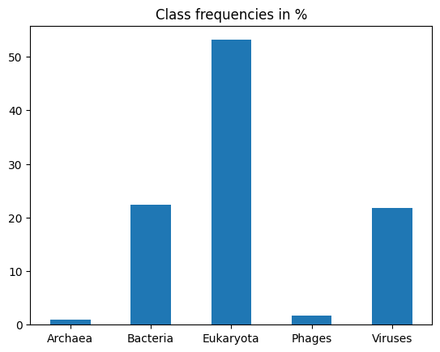

```python
class_frequencies = y.value_counts() / y.value_counts().sum() * 100
class_frequencies = class_frequencies.sort_index()
class_frequencies.index = [
    "Archaea",
    "Bacteria",
    "Eukaryota",
    "Phages",
    "Viruses",
]

ax = class_frequencies.plot.bar(rot=0)
plt.title("Class frequencies in %");
```

Jak widać, mamy nie tylko klasyfikację wieloklasową, ale na dodatek klasyfikację niezbalansowaną. W takim przypadku trzeba użyć odpowiednich metryk. Wzorując się na artykule, użyjemy **macro-averaged F1-score**. Jest to proste rozwinięcie F1-score na wiele klas.

Dla przypomnienia, w klasyfikacji binarnej, F1-score to średnia harmoniczna precyzji (precision) i czułości (recall):

$$ F1 = \frac{2}{recall^{-1} + precision^{-1}} = 2 * \frac{precision * recall}{precision + recall} = \frac{2 * TP}{2 * TP + FP + FN} $$

Macro-averaging oznacza, że najpierw obliczamy F1-score dla każdej klasy, a później bierzemy ich średnią. Żeby taka średnia była wysoka, to musimy mieć wysoki wynik na wszystkich 5 klasach, w tym 2 mniejszościowych, więc uwzględnimy niezbalansowanie klas.

```python
# This one is to ignore right now
# To facilitate data loading in CNN Task
def load_prepare_codon_data() -> tuple([pd.DataFrame, pd.Series]):
    df = pd.read_csv("codon_usage.csv")
    df = df[pd.to_numeric(df["UUU"], errors="coerce").notnull()].copy()

    df = df.copy()  # to avoid irritating SettingWithCopyWarning
    df["UUU"] = df.loc[:, "UUU"].astype(float)
    df["UUC"] = df.loc[:, "UUC"].astype(float)

    df = df.loc[~df["Ncodons"] < 1000, :]
    df = df.loc[df["Kingdom"] != "plm", :]
    df = df.drop(
        ["DNAtype", "SpeciesID", "Ncodons", "SpeciesName"], axis="columns"
    )

    kingdom_mapping = {
        "arc": 0,
        "bct": 1,
        "pln": 2,
        "inv": 2,
        "vrt": 2,
        "mam": 2,
        "rod": 2,
        "pri": 2,
        "phg": 3,
        "vrl": 4,
    }
    df = df.replace({"Kingdom": kingdom_mapping})
    y = df.pop("Kingdom")

    return df, y
```

## Klasyfikator kNN

Wytrenujemy teraz podstawowy algorytm k najbliższych sąsiadów, korzystając z samych wartości domyślnych ze Scikit-learn: 5 sąsiadów, metryka euklidesowa, brak ważenia.

Zgodnie z artykułem, wykorzystamy zwykłą metodę holdout do testowania, dzieląc zbiór na treningowy i testowy w proporcjach 80%-20%. Zrobimy to ze **stratyfikacją (stratification)**, czyli tak, żeby rozkład klas był taki sam w obu podzbiorach.

```python
from sklearn.model_selection import (
    train_test_split,
)


(X_train, X_test, y_train, y_test,) = train_test_split(
    df,
    y,
    test_size=0.2,
    random_state=0,
    stratify=y,
)
```

```python
from sklearn.metrics import f1_score
from sklearn.neighbors import (
    KNeighborsClassifier,
)


clf = KNeighborsClassifier(n_jobs=-1)
clf.fit(X_train, y_train)

y_pred_score_train = clf.predict(X_train)
y_pred_score_test = clf.predict(X_test)

f1_train = f1_score(
    y_train,
    y_pred_score_train,
    average="macro",
)
f1_test = f1_score(
    y_test,
    y_pred_score_test,
    average="macro",
)

print(f"F1 train: {100 * f1_train:.2f}%")
print(f"F1 test: {100 * f1_test:.2f}%")
```

```
F1 train: 92.51%
F1 test: 91.35%
```

Wyniki są całkiem niezłe, ale jest jeszcze miejsce na poprawę. Być może zmiana liczby sąsiadów albo metryki, albo też dodanie ważenia sąsiadów da nam jeszcze kilka procent.

W przypadku wielu klas samo agregowane F1 nie zawsze mówi jednak wszystko. Zawsze warto sprawdzić **macierz pomyłek (confusion matrix)**. Co ważne, można ją rysować albo z surową liczbą przykładów, albo znormalizować, żeby dostać wyniki w ułamku (zakres wartości 0-1). Pierwsza możliwość jest przydatna, kiedy mamy niezbalansowane klasy i patrzymy na ogólną jakość klasyfikatora. Znormalizowane wykresy są z kolei przydatne, kiedy przyglądamy się klasom z osobna.

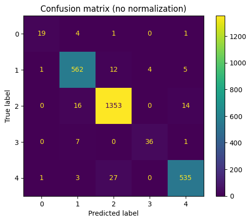

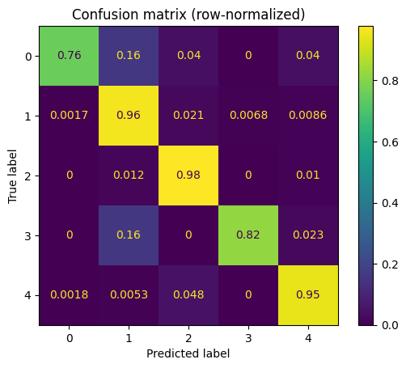

```python
from sklearn.metrics import (
    ConfusionMatrixDisplay,
)

cm = ConfusionMatrixDisplay.from_estimator(clf, X_test, y_test)
plt.title("Confusion matrix (no normalization)")
plt.show()


cm_norm = ConfusionMatrixDisplay.from_estimator(
    clf, X_test, y_test, normalize="true"
)
plt.title("Confusion matrix (row-normalized)")
plt.show()
```

Wyniki są całkiem niezłe, w końcu mamy wysokie F1. Widać jednak, że dość często mylimy klasę 0 (archeony) oraz klasę 3 (bakteriofagi) z klasą 1 (bakterie) - jest to problematyczne, ale zrozumiałe, bo tych klas jest najmniej.

Po tuningu powinniśmy otrzymać lepsze wyniki. Na dobry początek sprawdzimy różną liczbę sąsiadów. Trzeba zwrócić uwagę, że jeżeli nasza metryka ma jakieś argumenty, to trzeba użyć funkcji `make_scorer` i przekazać wynik do `GridSearchCV`.

Zwróć też uwagę, że skoro przekazujemy `n_jobs=-1` do klasyfikatora, to grid search dostaje `n_jobs=None`, żeby mieć tyle procesów, co rdzeni procesora. Przy okazji zmierzymy też czas tuningu.

```python
from time import time

from sklearn.metrics import make_scorer
from sklearn.model_selection import (
    GridSearchCV,
)


clf = KNeighborsClassifier(n_jobs=-1)

param_grid = {
    "n_neighbors": list(range(1, 51)),
}

multiclass_f1 = make_scorer(
    f1_score,
    average="macro",
    greater_is_better=True,
)

cv = GridSearchCV(
    estimator=clf,
    param_grid=param_grid,
    scoring=multiclass_f1,
    cv=5,
)

time_start = time()
cv.fit(X_train, y_train)
time_end = time()

print(f"Optimal number of neighbors: {cv.best_params_['n_neighbors']}")
print(f"Tuning time: {time_end - time_start:.2f} s")

y_pred_score_train = cv.predict(X_train)
y_pred_score_test = cv.predict(X_test)

f1_train = f1_score(
    y_train,
    y_pred_score_train,
    average="macro",
)
f1_test = f1_score(
    y_test,
    y_pred_score_test,
    average="macro",
)

print(f"F1 train: {100 * f1_train:.2f}%")
print(f"F1 test: {100 * f1_test:.2f}%")
```

```
Optimal number of neighbors: 1
Tuning time: 35.21 s
F1 train: 100.00%
F1 test: 89.16%
```

Co ciekawe, po tuningu nie tylko nie mamy lepszego wyniku, ale wręcz przeuczamy bardziej! Tak się niestety zdarza - tuning opiera się na wyniku na zbiorze walidacyjnym, które nie zawsze są dobrą estymatą. Pewnym sposobem na ominięcie tego jest zmniejszenie zakresu dla hiperparametru. Tutaj wiemy, że:

- im mniejsza liczba sąsiadów, tym większa wariancja (mocniejszy overfitting) i na odwrót
- domyślna liczba sąsiadów to 5
- przy 4 przeuczamy mocniej

Można więc po prostu sprawdzać zakres od 5 wzwyż. Do tego czeka nas jeszcze tuning metryki i ważenia sąsiadów.

**Zadanie 2 (1.5 punktu)**

1. Dokonaj tuningu: liczby sąsiadów (zakres [5, 25]), metryki (euklidesowa, Manhattan, cosinusowa) oraz ważenia sąsiadów (brak vs ważenie odległością). Jakie są optymalne wartości hiperparametrów?
2. Zmierz czas. Czy twoim zdaniem to długo, dla zbioru, który ma ok. 10k próbek uczących?
3. Narysuj macierz pomyłek dla zbioru testowgeo. Czy wygląda sensownie, szczególnie dla klas mniejszościowych? Czy udało się uzyskać wynik lepszy od bazowego?

```python
clf = KNeighborsClassifier(n_jobs=-1)

param_grid = {
    "n_neighbors": list(range(5, 26)),
    "metric": ["euclidean", "manhattan", "cosine"],
    "weights": ["uniform", "distance"],
}

cv = GridSearchCV(
    estimator=clf,
    param_grid=param_grid,
    scoring=multiclass_f1,
    cv=5,
)

time_start = time()
cv.fit(X_train, y_train)
time_end = time()

print(f"Optimal number of neighbors: {cv.best_params_['n_neighbors']}")
print(f"Optimal metric: {cv.best_params_['metric']}")
print(f"Optimal weights: {cv.best_params_['weights']}")
print(f"Best params: {cv.best_params_}")
print(f"Tuning time: {time_end - time_start:.2f} s")

y_pred_score_train = cv.predict(X_train)
y_pred_score_test = cv.predict(X_test)

f1_train = f1_score(y_train, y_pred_score_train, average="macro")
f1_test = f1_score(y_test, y_pred_score_test, average="macro")

print(f"F1 train: {100 * f1_train:.2f}%")
print(f"F1 test: {100 * f1_test:.2f}%")
```

```
Optimal number of neighbors: 6
Optimal metric: cosine
Optimal weights: distance
Best params: {'metric': 'cosine', 'n_neighbors': 6, 'weights': 'distance'}
Tuning time: 190.11 s
F1 train: 100.00%
F1 test: 91.53%
```

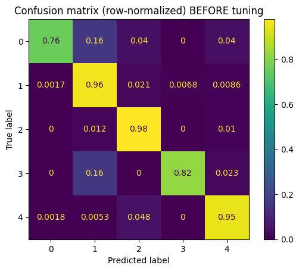

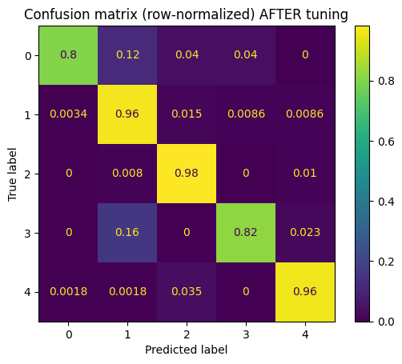

```python
cm_norm.plot()
plt.title("Confusion matrix (row-normalized) BEFORE tuning")
plt.show()

ConfusionMatrixDisplay.from_estimator(cv, X_test, y_test, normalize="true")
plt.title("Confusion matrix (row-normalized) AFTER tuning")
plt.show()
```

// skomentuj tutaj

1. Optymalnymi wartościami hiperparametrów okazały się być:
- metric: cosine,
- n_neighbors: 6,
- weights: distance (ważenie odległością)

Osiągnięto:

`F1 train: 100.00%` => stan przeuczenia

`F1 test: 91.53%` => minimalnie lepszy wynik dla zbioru testowego

(przed tuningiem było:

`F1 train: 92.51%`

`F1 test: 91.35%`)

Patrząc na czyste statystyki F1-score: z F1-train 100% wynika, że doszło do przeuczenia modelu, a F1-test jest minimalnie lepsze. Ostatecznie więc korzyści na tym zbiorze testowym ze zbytniego wyuczenia modelu są znikome, możliwe, że na innych danych testowych model wypadłby gorzej, biorąc pod uwagę przeuczenie. Na tym zestawie testowym wypadł jednak ciut lepiej niż bazowy.

## Approximate Nearest Neighbors (ANN)

Postaramy się teraz przyspieszyć nasz klasyfikator, w zamian za odrobinę dokładności, za pomocą algorytmu przybliżonych najbliższych sąsiadów, a konkretnie [NN-Descent](https://pynndescent.readthedocs.io/en/latest/index.html). Ten został wybrany głównie ze względu na łatwą w użyciu implementację.

Twórcy Scikit-learn'a zdawali sobie sprawę, że algorytmy znajdowania najbliższych sąsiadów to aktywne pole rozwoju, dlatego stworzyli klasę (i interfejs) `KNeighborsTransformer`, pozwalającą integrować zewnętrzne rozwiązania. Działa ona zarówno do klasyfikacji / regresji kNN, jak i do innych algorytmów opartych o sąsiedztwo, które budują graf najbliższych sąsiadów. W przypadku jego użycia trzeba podać `metric="precomputed"`, bo obliczaniem odległości zajmuje się osobny algorytm.

Implementacja PyNNDescent korzysta właśnie z tego rozwiązania, co gwarantuje łatwość użycia - klasa `PyNNDescentTransformer` dziedziczy po `KNeighborsTransformer`. Zobaczmy, jak to działa. Wykorzystamy funkcję `make_pipeline()`, która buduje obiekt `Pipeline`, ale nie wymaga podawania nazw kolejnych elementów.

**Uwaga:** PyNNDescent dla wydajności korzysta z Numby, czyli kompilatora JIT (Just-In-Time). Dzięki temu działa to bardzo szybko, ale pierwszy import i wykonanie zajmuje sporo czasu. Wykonaj kod 2 razy - za drugim razem będzie o wiele szybciej.

```python
from time import time


def benchmark_knn_and_ann(
    sklearn_knn,
    pynndescent_ann,
    X_train,
    X_test,
    y_train,
    y_test,
) -> None:
    # training
    start_time = time()
    sklearn_knn.fit(X_train, y_train)
    end_time = time()

    sklearn_knn_fit_time = end_time - start_time

    start_time = time()
    pynndescent_ann.fit(X_train, y_train)
    end_time = time()

    pynndescent_ann_fit_time = end_time - start_time

    # prediction

    start_time = time()
    y_pred_sklearn = sklearn_knn.predict(X_test)
    end_time = time()

    sklearn_knn_predict_time = end_time - start_time

    start_time = time()
    y_pred_pynndescent = pynndescent_ann.predict(X_test)
    end_time = time()

    pynndescent_ann_predict_time = end_time - start_time

    f1_knn = f1_score(
        y_test,
        y_pred_sklearn,
        average="macro",
    )
    f1_ann = f1_score(
        y_test,
        y_pred_pynndescent,
        average="macro",
    )

    print(f"Scikit-learn training time: {sklearn_knn_fit_time:.2f}")
    print(f"PyNNDescent training time: {pynndescent_ann_fit_time:.2f}")
    print()
    print(f"Scikit-learn prediction time: {sklearn_knn_predict_time:.2f}")
    print(f"PyNNDescent prediction time: {pynndescent_ann_predict_time:.2f}")
    print()
    print(f"Scikit-learn F1: {100 * f1_knn:.2f}%")
    print(f"PyNNDescent F1: {100 * f1_ann:.2f}%")
```

```python
from pynndescent import (
    PyNNDescentTransformer,
)
from sklearn.pipeline import make_pipeline


sklearn_knn = KNeighborsClassifier(metric="euclidean")

pynndescent_ann = make_pipeline(
    PyNNDescentTransformer(metric="euclidean", random_state=0),
    KNeighborsClassifier(metric="precomputed"),
)

benchmark_knn_and_ann(
    sklearn_knn,
    pynndescent_ann,
    X_train,
    X_test,
    y_train,
    y_test,
)
```

```
Scikit-learn training time: 0.01
PyNNDescent training time: 2.35

Scikit-learn prediction time: 0.15
PyNNDescent prediction time: 0.13

Scikit-learn F1: 91.35%
PyNNDescent F1: 91.25%
```

Czas treningu jest dłuższy - to oczekiwany wynik. Natomiast czas predykcji jest podobny - wynika to z tego, że dla metryki euklidesowej k-d tree jest bardzo wydajne. Wynik jest bardzo podobny, więc mamy dobre przybliżenie.

Sprawdźmy metrykę Manhattan, dla której typowo k-d tree radzi sobie nieco gorzej.

```python
sklearn_knn = KNeighborsClassifier(metric="manhattan")

pynndescent_ann = make_pipeline(
    PyNNDescentTransformer(metric="manhattan", random_state=0),
    KNeighborsClassifier(metric="precomputed"),
)

benchmark_knn_and_ann(
    sklearn_knn,
    pynndescent_ann,
    X_train,
    X_test,
    y_train,
    y_test,
)
```

```
Scikit-learn training time: 0.01
PyNNDescent training time: 2.26

Scikit-learn prediction time: 0.47
PyNNDescent prediction time: 0.13

Scikit-learn F1: 91.39%
PyNNDescent F1: 91.39%
```

Tutaj predykcja ANN jest już wyraźnie szybsza - co prawda dane są niezbyt duże, więc nie ma to aż takiego znaczenia, ale widać potencjał skalowalności. Dodatkowo wynik jest taki sam.

## Zbiór danych - klasyfikacja danych chemicznych

Teraz zajmiemy się klasyfikacją zbioru posiadającego same zmienne binarne, do których trzeba użyć odpowiednich metryk. Konkretnie, będzie to zbiór [HIV z benchmarku MoleculeNet](https://moleculenet.org/datasets-1), w którym na podstawie reprezentacji chemicznej molekuły trzeba przewidywać, czy jest ona inhibitorem wirusa HIV. [Inhibitory](https://en.wikipedia.org/wiki/Reaction_inhibitor) to substancje przeciwne do katalizatorów - spowalniają lub uniemożliwiają jakieś zjawisko, w naszym wypadku infekcję wirusa HIV. Przewidywanie własności molekuł to kluczowe zadanie w nowoczesnym projektowaniu leków i bardzo ważne zastosowanie ML w farmacji i chemii molekularnej.

Zbiór jest już podzielony na treningowy, walidacyjny i testowy w ramach projektu [Open Graph Benchmark](https://ogb.stanford.edu/docs/graphprop/). Dane te można traktować jak klasyfikację grafów molekularnych, ale w naszym wypadku zostały już one przetworzone do postaci tabelarycznej algorytmem [ECFP4 fingerprint](https://docs.chemaxon.com/display/docs/extended-connectivity-fingerprint-ecfp.md). Konkretnie, z molekuł wyciągnięto informacje o 1024 podgrafach, gdzie wartość zmiennej mówi, czy dana struktura występuje w molekule, czy też nie.

Jako że zbiór jest binarny, to nie ma potrzeby żadnego skalowania zmiennych.

W przypadku tego zbioru oficjalną metryką [w benchmarku](https://ogb.stanford.edu/docs/leader_graphprop/) jest Area Under Receiver Operating Characteristic (AUROC / ROC AUC).

[figure not shown]

**Zadanie 3 (1 punkt)**

1. Wczytaj zbiory treningowy, walidacyjny i testowy. Są one w postaci plików Parquet.
2. Wyodrębnij klasę `y` do osobnych zmiennych `y_train`, `y_valid`, `y_test`.
3. Przekonwertuj macierze `X_train`, `X_valid` i `X_test` na typ bool ([przydatne pytanie na StackOverflow](https://stackoverflow.com/questions/20373039/how-do-i-convert-a-numpy-matrix-into-a-boolean-matrix)) - tak przechowywane dane zajmują mniej miejsca.
4. Narysuj wykres częstości klas w zbiorze treningowym. Jak sądzisz, czemu akurat AUROC zostało tutaj wybrane jako metryka?

```python
mol_train = pd.read_parquet("mol_hiv_train.parquet")
mol_val = pd.read_parquet("mol_hiv_valid.parquet")
mol_test = pd.read_parquet("mol_hiv_test.parquet")
```

```python
y_train = mol_train.pop("y")
y_valid = mol_val.pop("y")
y_test = mol_test.pop("y")
```

```python
X_train = np.array(mol_train, dtype=bool)
X_valid = np.array(mol_val, dtype=bool)
X_test = np.array(mol_test, dtype=bool)
```

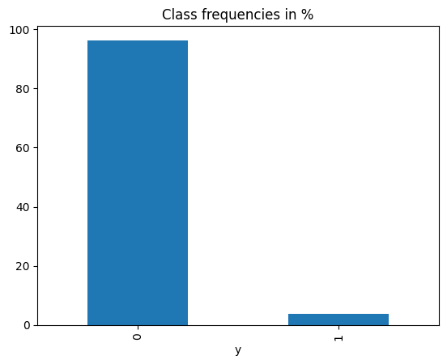

```python
class_frequencies = y_train.value_counts() / y_train.value_counts().sum() * 100
class_frequencies = class_frequencies.sort_index()
ax = class_frequencies.plot.bar()
plt.title("Class frequencies in %");
```

Jak widać, klasy są silnie niezbalansowane - z tego powodu użycie samego F1 nie dałoby dobrego wyniku. Potrzebne jest wykreślenie krzywych ROC i porównanie ich dla różnych klasyfikatorów, co można zautomatyzować licząc AUC.

```python
# For CNN additional task purposes only
def load_prepare_molhiv_data():
    mol_train = pd.read_parquet("mol_hiv_train.parquet")
    mol_val = pd.read_parquet("mol_hiv_valid.parquet")
    mol_test = pd.read_parquet("mol_hiv_test.parquet")

    y_train = mol_train.pop("y")
    y_valid = mol_val.pop("y")
    y_test = mol_test.pop("y")

    X_train = np.array(mol_train, dtype=bool)
    X_valid = np.array(mol_val, dtype=bool)
    X_test = np.array(mol_test, dtype=bool)

    return X_train, X_valid, X_test, y_train, y_valid, y_test
```

**Zadanie 4 (1.5 punktu)**

1. Wytrenuj klasyfikator kNN z domyślnymi hiperparametrami, używając metryki Jaccarda (Tanimoto). Zmierz AUROC na zbiorze testowym. Pamiętaj, żeby przekazać odpowiednie wartości do metryki (patrz [przykład w dokumentacji](https://scikit-learn.org/stable/modules/generated/sklearn.metrics.roc_auc_score.html)).
2. Zmierz czas treningu oraz predykcji. Czy podczas treningu została zbudowana jakakolwiek struktura danych?
3. Dokonaj tuningu liczby sąsiadów z zakresu [1, 5, 10]. Wykorzystaj tutaj istniejący zbiór walidacyjny z pomocą `PredefinedSplit`. Może się przydać [ta odpowiedź na StackOverflow](https://stackoverflow.com/a/70155766/9472066). Do tuningu wykorzystaj metrykę AUROC (argument `scoring`).
4. Porównaj wyniki algorytmu po tuningu [z oficjalnym leaderboardem](https://ogb.stanford.edu/docs/leader_graphprop/).

```python
# from scipy.spatial.distance import jaccard
from sklearn.metrics import jaccard_score
from sklearn.metrics import roc_auc_score

from sklearn.neighbors import KNeighborsClassifier
from time import time

from sklearn.metrics import make_scorer
from sklearn.model_selection import GridSearchCV
```

#### kNN

- default hyperparams,
- Jaccard (Tanimoto) metric

##### Fitting time

```python
clf = KNeighborsClassifier(n_jobs=-1, metric="jaccard")

time_start = time()
clf.fit(X_train, y_train)
time_end = time()
```

```python
print("kNN with default hyperparameters, Jaccard metric")
print(f"Fitting time: {time_end - time_start:.2f} sec")
```

```
kNN with default hyperparameters, Jaccard metric
Fitting time: 0.06 sec
```

Podczas treningu nie została zbudowana struktura danych typu drzewiastego/grafowego, zostały po prostu zapamiętane obserwacje i ich etykiety.

##### Predict_proba time

```python
time_start = time()
y_pred_proba = clf.predict_proba(X_test)
time_stop = time()
```

```python
print(f"Predic_proba time: {time_stop - time_start:.2f}")
```

```
Predic_proba time: 75.63
```

##### Predict time

```python
time_start = time()
y_pred = clf.predict(X_test)
time_stop = time()
```

```python
print(f"Predict time: {time_stop - time_start:.2f} s")
```

```
Predict time: 72.16 s
```

##### Clf params

```python
attr = [
    clf.classes_,
    clf.effective_metric_,
    clf.effective_metric_params_,
    clf.n_features_in_,
    clf.n_samples_fit_,
    clf.outputs_2d_,
]
attr_names = [
    "Class labels known to the classifier",
    "Effective metric",
    "Effective metric params",
    "Fit number of features",
    "Fit number of samples",
    "Output 2d",
]

print("Classifier attributes\n")
for a, a_name in zip(attr, attr_names):
    print(f"{a_name}: {a}")

print("")
print(clf.get_params())
```

```
Classifier attributes

Class labels known to the classifier: [0 1]
Effective metric: jaccard
Effective metric params: {}
Fit number of features: 1024
Fit number of samples: 32901
Output 2d: False

{'algorithm': 'auto', 'leaf_size': 30, 'metric': 'jaccard', 'metric_params': None, 'n_jobs': -1, 'n_neighbors': 5, 'p': 2, 'weights': 'uniform'}
```

#### Scores

```python
# AUROC
y_score = roc_auc_score(y_test, y_pred_proba[:, 1])
print(f"AUROC: {y_score:.4f}")

# clf.score
clf_score = clf.score(X_test, y_test)
print(f"clf.score: {clf_score:.4f}")

# jaccard_score
clf_jaccard = jaccard_score(y_test, y_pred)
print(f"Clf jaccard score: {clf_jaccard:.4f}")
```

```
AUROC: 0.7387
clf.score: 0.9696
Clf jaccard score: 0.1554
```

#### Tuning

```python
# Example - for educational purposes only

# X = np.array([[1, 2], [3, 4], [1, 2], [3, 4]])
# test_fold = [0]*2 + [2]*1 + [3]*1
# ps = PredefinedSplit(test_fold)
# print("Number of splits: ", ps.get_n_splits(), "\n")

# for i, (train_index, test_index) in enumerate(ps.split()):
#     print(f"Fold {i}:")
#     print(f"  Train: index={train_index}")
#     print(f"  Test:  index={test_index}")
```

```python
from sklearn.model_selection import PredefinedSplit


split_index = [-1] * len(X_train) + [0] * len(X_valid)
pds = PredefinedSplit(test_fold=split_index)

print("Number of splits: ", pds.get_n_splits(), "\n")

for i, (train_index, test_index) in enumerate(pds.split()):
    print(f"Fold {i}:")
    print(f"  Train: index={train_index}")
    print(f"  Test:  index={test_index}")
```

```
Number of splits:  1

Fold 0:
  Train: index=[    0     1     2 ... 32898 32899 32900]
  Test:  index=[32901 32902 32903 ... 37011 37012 37013]
```

```python
param_grid = {
    "n_neighbors": list([1, 5, 10]),
}

cv = GridSearchCV(
    estimator=clf,
    param_grid=param_grid,
    scoring="roc_auc",
    cv=pds,
)

X = np.concatenate((X_train, X_valid), axis=0)
y = np.concatenate((y_train, y_valid), axis=0)

time_start = time()
cv.fit(X, y)
time_end = time()
```

#### Best params

```python
print(f"Optimal number of neighbors: {cv.best_params_['n_neighbors']}")
print(f"Best params: {cv.best_params_}")
print(f"Tuning time: {time_end - time_start:.2f} s")
```

```
Optimal number of neighbors: 10
Best params: {'n_neighbors': 10}
Tuning time: 223.88 s
```

```python
cv.cv_results_
```

```
{'mean_fit_time': array([0.04367757, 0.05099988, 0.0510025 ]),
 'std_fit_time': array([0., 0., 0.]),
 'mean_score_time': array([74.12282252, 75.26930475, 74.27204704]),
 'std_score_time': array([0., 0., 0.]),
 'param_n_neighbors': masked_array(data=[1, 5, 10],
              mask=[False, False, False],
        fill_value='?',
             dtype=object),
 'params': [{'n_neighbors': 1}, {'n_neighbors': 5}, {'n_neighbors': 10}],
 'split0_test_score': array([0.65761409, 0.74456202, 0.75252915]),
 'mean_test_score': array([0.65761409, 0.74456202, 0.75252915]),
 'std_test_score': array([0., 0., 0.]),
 'rank_test_score': array([3, 2, 1])}
```

```python
attr = [
    cv.best_estimator_,
    cv.best_score_,
    cv.best_params_,
    cv.best_index_,
    cv.scorer_,
    cv.n_splits_,
    cv.refit_time_,
    cv.multimetric_,
    cv.classes_,
    cv.n_features_in_,
]
attr_names = [
    "Best estimator",
    "Best score (only if refit is specified)",
    "Best params",
    "Best index",
    "Scorer",
    "Number of cv splits (folds/iterations)",
    "Refit time (if refit is not False)",
    "Multimetric - whether or not scorers compute several metrics",
    "Class labels",
    "Number of features during fit",
]

print("Classifier attributes\n")
for a, a_name in zip(attr, attr_names):
    print(f"{a_name}: {a}")
```

```
Classifier attributes

Best estimator: KNeighborsClassifier(metric='jaccard', n_jobs=-1, n_neighbors=10)
Best score (only if refit is specified): 0.7525291495198903
Best params: {'n_neighbors': 10}
Best index: 2
Scorer: make_scorer(roc_auc_score, response_method=('decision_function', 'predict_proba'))
Number of cv splits (folds/iterations): 1
Refit time (if refit is not False): 0.04999899864196777
Multimetric - whether or not scorers compute several metrics: False
Class labels: [0 1]
Number of features during fit: 1024
```

```python
print(f"Cv best score on trainvalid data: {cv.best_score_:.4f}")
```

```
Cv best score on trainvalid data: 0.7525
```

##### Predict_proba time

```python
time_start = time()
y_pred_score_test = cv.predict_proba(X_test)
time_end = time()
```

```python
print(f"Predict time: {time_end - time_start:.2f} s")
```

```
Predict time: 84.66 s
```

##### Predict time

```python
time_start = time()
y_pred_score_test = cv.predict(X_test)
time_end = time()
```

```python
print(f"Predict time: {time_end - time_start:.2f} s")
```

```
Predict time: 80.02 s
```

#### AUROC on test data

```python
y_score = roc_auc_score(y_test, y_pred_proba[:, 1])
print(f"AUROC score on test data: {y_score:.4f}")
```

```
AUROC score on test data: 0.7387
```

**Zadanie 5 (1.5 punktu)**

1. Stwórz pipeline do klasyfikacji ANN z użyciem PyNNDescent. Wykorzystaj metrykę Jaccarda (Tanimoto) i znalezioną wcześniej optymalną liczbę sąsiadów.
2. Wytrenuj zwykłe kNN oraz ANN oraz dokonaj predykcji. Zmierz czas oraz dokładność obu metod. Czy twoim zdaniem warto dokonać w tym wypadku takiej aproksymacji?

```python
def benchmark_knn_and_ann(
    sklearn_knn,
    pynndescent_ann,
    X_train,
    X_test,
    y_train,
    y_test,
) -> None:
    # training
    start_time = time()
    sklearn_knn.fit(X_train, y_train)
    end_time = time()
    sklearn_knn_fit_time = end_time - start_time

    start_time = time()
    pynndescent_ann.fit(X_train, y_train)
    end_time = time()
    pynndescent_ann_fit_time = end_time - start_time

    # prediction
    start_time = time()
    y_pred_sklearn = sklearn_knn.predict(X_test)
    end_time = time()
    sklearn_knn_predict_time = end_time - start_time

    start_time = time()
    y_pred_pynndescent = pynndescent_ann.predict(X_test)
    end_time = time()
    pynndescent_ann_predict_time = end_time - start_time

    # proba prediction
    start_time = time()
    y_pred_proba_sklearn = sklearn_knn.predict_proba(X_test)
    end_time = time()
    sklearn_knn_predict_proba_time = end_time - start_time

    start_time = time()
    y_pred_proba_pynndescent = pynndescent_ann.predict_proba(X_test)
    end_time = time()
    pynndescent_ann_predict_proba_time = end_time - start_time

    # scores
    f1_knn = f1_score(y_test, y_pred_sklearn, average="macro")
    f1_ann = f1_score(y_test, y_pred_pynndescent, average="macro")

    score_knn = sklearn_knn.score(X_test, y_test)
    score_ann = pynndescent_ann.score(X_test, y_test)

    auroc_knn = roc_auc_score(y_test, y_pred_proba_sklearn[:, 1])
    auroc_ann = roc_auc_score(y_test, y_pred_proba_pynndescent[:, 1])

    jaccard_knn = jaccard_score(y_test, y_pred_sklearn)
    jaccard_ann = jaccard_score(y_test, y_pred_pynndescent)

    print(f"Scikit-learn training time: {sklearn_knn_fit_time:.2f} s")
    print(f"PyNNDescent training time: {pynndescent_ann_fit_time:.2f} s")
    print()
    print(f"Scikit-learn prediction time: {sklearn_knn_predict_time:.2f} s")
    print(f"PyNNDescent prediction time: {pynndescent_ann_predict_time:.2f} s")
    print()
    print(
        f"Scikit-learn predict_proba time: \
        {sklearn_knn_predict_proba_time:.2f} s"
    )
    print(
        f"PyNNDescent predict_proba time: \
        {pynndescent_ann_predict_proba_time:.2f} s"
    )

    print()
    print(f"Scikit-learn F1: {100 * f1_knn:.2f}%")
    print(f"PyNNDescent F1: {100 * f1_ann:.2f}%")
    print()
    print(f"Scikit-learn score: {100 * score_knn:.2f}%")
    print(f"PyNNDescent score: {100 * score_ann:.2f}%")
    print()
    print(f"Scikit-learn AUROC: {100 * auroc_knn:.2f}%")
    print(f"PyNNDescent AUROC: {100 * auroc_ann:.2f}%")
    print()
    print(f"Scikit-learn jaccard score: {100 * jaccard_knn:.2f}%")
    print(f"PyNNDescent jaccard score: {100 * jaccard_ann:.2f}%")

    print()
    print(f"Scikit-learn n_neighbors: {sklearn_knn.n_neighbors}")
    print(
        f"PyNNDescent n_neighbors: \
        {pynndescent_ann.named_steps['pynndescenttransformer'].n_neighbors}"
    )
```

#### Mini benchmark - comparison based on the number of neighbors used to create ann graph and the number of neighbors used in knn search

##### PyNNDescent k = 30 (default), KNN k = 10

```python
sklearn_knn = KNeighborsClassifier(metric="jaccard", n_neighbors=10, n_jobs=-1)

pynndescent_ann = make_pipeline(
    PyNNDescentTransformer(metric="jaccard", random_state=0),
    KNeighborsClassifier(metric="precomputed", n_neighbors=10, n_jobs=-1),
)

benchmark_knn_and_ann(
    sklearn_knn, pynndescent_ann, X_train, X_test, y_train, y_test
)
```

```
Scikit-learn training time: 0.05 s
PyNNDescent training time: 9.47 s

Scikit-learn prediction time: 73.38 s
PyNNDescent prediction time: 1.59 s

Scikit-learn predict_proba time:         85.95 s
PyNNDescent predict_proba time:         1.69 s

Scikit-learn F1: 61.45%
PyNNDescent F1: 60.88%

Scikit-learn score: 97.13%
PyNNDescent score: 97.11%

Scikit-learn AUROC: 75.33%
PyNNDescent AUROC: 75.08%

Scikit-learn jaccard score: 13.87%
PyNNDescent jaccard score: 13.14%

Scikit-learn n_neighbors: 10
PyNNDescent n_neighbors:         30
```

Results: AUROC zarówno dla PyNNDescent jak i Scikit learn są lepsze niż w poprzednim zadaniu. W tym przypadku wynika to ze zbudowania dość dokładnego grafu ann (30 sąsiadów - wartość defaultowa). Obydwa wyniki AUROC są do siebie zbliżone. Czas PNNDescent do predykcji super.

##### PyNNDescent k = 10, KNN k = 10

```python
sklearn_knn = KNeighborsClassifier(metric="jaccard", n_neighbors=10, n_jobs=-1)

pynndescent_ann = make_pipeline(
    PyNNDescentTransformer(metric="jaccard", random_state=0, n_neighbors=10),
    KNeighborsClassifier(metric="precomputed", n_neighbors=10, n_jobs=-1),
)

benchmark_knn_and_ann(
    sklearn_knn, pynndescent_ann, X_train, X_test, y_train, y_test
)
```

```
Scikit-learn training time: 0.05 s
PyNNDescent training time: 5.82 s

Scikit-learn prediction time: 73.42 s
PyNNDescent prediction time: 0.57 s

Scikit-learn predict_proba time:         82.11 s
PyNNDescent predict_proba time:         0.52 s

Scikit-learn F1: 61.45%
PyNNDescent F1: 61.45%

Scikit-learn score: 97.13%
PyNNDescent score: 97.13%

Scikit-learn AUROC: 75.33%
PyNNDescent AUROC: 70.84%

Scikit-learn jaccard score: 13.87%
PyNNDescent jaccard score: 13.87%

Scikit-learn n_neighbors: 10
PyNNDescent n_neighbors:         10
```

Results: Tutaj już widać różnice między PyNNDescent i Scikit learn w AUROC - 5%, to sporo. Czas budowy grafu ann jest krótszy niż w poprzednim przykładzie, bo tam budowaliśmy dla 30 sąsiadów, a tutaj dla 10. Czas predykcji jeszcze szybszy - 1/3 poprzedniego wyniku. Jednak ta spora różnica w AUROC'ach martwiąca.

##### PyNNDescent k = 10, KNN k = 10 - without passing this value explicite to the KNN constructor - just through pipeline)

```python
sklearn_knn = KNeighborsClassifier(metric="jaccard", n_neighbors=10, n_jobs=-1)

pynndescent_ann = make_pipeline(
    PyNNDescentTransformer(metric="jaccard", random_state=0, n_neighbors=10),
    KNeighborsClassifier(metric="precomputed", n_jobs=-1),
)

benchmark_knn_and_ann(
    sklearn_knn, pynndescent_ann, X_train, X_test, y_train, y_test
)
```

```
Scikit-learn training time: 0.05 s
PyNNDescent training time: 5.63 s

Scikit-learn prediction time: 71.75 s
PyNNDescent prediction time: 0.49 s

Scikit-learn predict_proba time:         79.23 s
PyNNDescent predict_proba time:         0.41 s

Scikit-learn F1: 61.45%
PyNNDescent F1: 62.42%

Scikit-learn score: 97.13%
PyNNDescent score: 96.89%

Scikit-learn AUROC: 75.33%
PyNNDescent AUROC: 71.15%

Scikit-learn jaccard score: 13.87%
PyNNDescent jaccard score: 15.23%

Scikit-learn n_neighbors: 10
PyNNDescent n_neighbors:         10
```

Results: AUROC dla PyNNDescent troszeczkę poprawiony, choć różnica wciąż spora względem Scikit-learn. Co ciekawe, udało się wreszcie poprawić choć troszkę jaccard score.

### Task conclusions

1. Najlepsze rezultaty otrzymano dla dokładniejszego grafu PyNNDescent (defaultowe k = 30):

`Scikit-learn AUROC: 75.33%`

`PyNNDescent AUROC: 75.08%`.

2. Dla mniej dokładnego grafu PyNNDescent (k = 10) widać jednak te 4% różnicy w AUROC, dlatego warto budować dokładniejsze grafy.
3. Czy warto dokonać takiej aproksymacji? Zależy od potrzeby. Gdybym miała wykorzystać te obliczenia w prawdziwych celach praktycznych (analiza danych prowadząca do wniosków o ważnym zastosowaniu), postawiłabym w tym wypadku na dokładny knn. Natomiast gdybym np. chciała zaprojektować jakieś ulepszenia algorytmu (np. jakiś mądry partition danych, jakieś sprytne odamiany knn itp.) korzystałabym z przybliżonego grafu sąsiadów ann (gdyż częst się wykonuje kod, uruchamia cellki itp.), a na sam koniec skorzystała z dokładnego knn.

## Wyszukiwanie z pomocą najbliższych sąsiadów

Naszym ostatnim zastosowaniem metod opartych o sąsiedztwo będzie wyszukiwanie przedmiotów. Konkretnie stworzymy wyszukiwarkę obrazów na podstawie wpisanego hasła.

Jest to zadanie **multimodalne (multimodal)**, bo operujemy na dwóch różnych modalnościach: obrazie i tekście. Takie wyszukiwarki działają następująco:

1. W fazie treningu przedmioty (obrazy) są wektoryzowane siecią neuronową i przechowywane w indeksie.
2. Użytkownik wpisuje tekst, który jest wektoryzowany za pomocą tej samej sieci neuronowej, dlatego musi być ona multimodalna.
3. Wyszukujemy najbliższych sąsiadów (obrazy-wektory) dla tekstu-wektora.

Najbardziej znanym modelem multimodalnym jest [CLIP](https://openai.com/research/clip), stworzony przez OpenAI. Jego architektura i wagi są dostępne publicznie, w przeciwieństwie do nowych rozwiązań tej firmy. Jest to model zasadniczo niewymagający fine-tuningu, działa bardzo dobrze w podstawowej formie dla wielu zadań. Został też wykorzystany jako element modelu [DALL-E 2](https://openai.com/product/dall-e-2).

Nie musisz szczegółowo wiedzieć, jak działa ten model, ale pewne podstawy są bardzo ciekawe i przydatne. Wysokopoziomowo architekturę dobrze opisuje [ten artykuł](https://towardsdatascience.com/clip-the-most-influential-ai-model-from-openai-and-how-to-use-it-f8ee408958b1). Dla zainteresowanych [cały artykuł](https://cdn.openai.com/papers/Learning_Transferable_Visual_Models_From_Natural_Language.pdf), znacznie bardziej szczegółowy. CLIP składa się z dwóch enkoderów: dla tekstu i dla obrazu. Są to zwykłe pre-trenowane sieci, a konkretnie:

1. Dla obrazu - [Visual Transformer (ViT)](https://www.v7labs.com/blog/vision-transformer-guide). Jest to architektura, która używa transformerów i atencji do przetwarzania obrazów. Ideą jest, żeby pociąć obraz na sąsiadujące kawałki (patches), i traktować je jak słowa dla atencji.
2. Dla tekstu - [Transformer](https://machinelearningmastery.com/the-transformer-model/), z pewnymi modyfikacjami.

Każda z tych sieci wektoryzuje wejście, dając embedding.

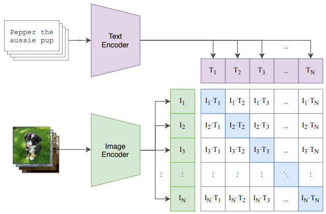

Zbiorem danych była kolekcja 400 milionów par (obraz, tekst), gdzie tekst opisywał zawartość obrazu. Następnie wykonano **constrastive pre-training** - model dostaje batch $N$ par (obraz, tekst) i ma przewidzieć, które z $N \times N$ możliwych kombinacji (obraz, tekst) faktycznie wystąpiły. W tym celu maksymalizuje podobieństwo cosinusowe par, które wystąpiły w batchu, a minimalizuje podobieństwo dla $N^2 - N$ możliwych kombinacji, których nie było w batchu. W tym celu jest używana entropia krzyżowa z pewnymi modyfikacjami.

Widać więc, że model jest nienadzorowany, a zbiór danych był ogromny, więc fine-tuning nie jest nam zasadniczo potrzebny. Można go użyć do klasyfikacji, ale tym nie będziemy się zajmować. Dodatkowo odpowiednią metryką odległości dla najbliższych sąsiadów będzie podobieństwo cosinusowe.

Biblioteka [Sentence-Transformers](https://www.sbert.net/index.html) powstała dla różnych modeli transformerowych do zadań nienadzorowanych, ale dodano do niej także bardzo wygodny interfejs dla modelu CLIP - [przykład użycia](https://www.sbert.net/examples/applications/image-search/README.html).

Jako zbiór wykorzystamy [Amazon Berkeley Objects (ABO) Dataset](https://amazon-berkeley-objects.s3.amazonaws.com/index.html) - zbiór obrazów produktów Amazona, stworzony we współpracy z University of California, Berkeley. Wykorzystamy [zminiaturyzowany zbiór](https://amazon-berkeley-objects.s3.amazonaws.com/archives/abo-images-small.tar), w którym obrazy mają rozmiar 256x256 pikseli, bo na nasze potrzeby jest zupełnie wystarczający.

**Zadanie 6 (3 punkty)**

*Wyszukiwarka z ANN*

1. Ściągnij [zbiór danych](https://amazon-berkeley-objects.s3.amazonaws.com/archives/abo-images-small.tar). Rozpakuj go obok tego notebooka. W katalogu `images/metadata` znajdziesz plik `images.csv.gz` - rozpakuj go obok tego notebooka, zawiera on ścieżki do obrazów.
2. Uzupełnij kod funkcji `vectorize_images`, która oblicza embeddingi obrazów za pomocą modelu CLIP. Przyda ci się [ten tutorial](https://www.sbert.net/examples/applications/image-search/README.html). Ustaw wartość MAX_IMAGES tak, żeby wystarczyło ci RAMu i żeby proces trwał rozsądną ilość czasu (ale co najmniej kilka-kilkanaście minut). `start_idx` oraz `end_idx` to indeksy wierszy, na których w danej chwili operujemy - po prostu przesuwamy się o `BATCH_SIZE` w pętli for.
3. Uzupełnij kod klasy `ImageSearch`:
- w konstruktorze stwórz indeks za pomocą klasy NNDescent, korzystając z metryki cosinusowej i `random_state=0`, może się też przydać `n_jobs=-1`
- w metodzie `query` zwektoryzuj zapytanie tekstowe, a następ wyszukaj indeksy najbliższych sąsiadów-obrazów w indeksie (zwróć uwagę na to, co zwraca metoda `.query()` dla `NNDescent`), a następnie zwróć ścieżki do ich obrazów; zwróć uwagę na to, że `.query()` wymaga 2-wymiarowego wejścia, więc w naszym wypadku `(1, 512)`
- w metodzie `show_images` załaduj i wyświetl obrazy; może się przydać [ten przykład](https://matplotlib.org/stable/gallery/axes_grid1/simple_axesgrid.html)
4. Przetestuj wyszukiwarkę kilkoma hasłami (metoda `.search()`). Prawdopodobnie najlepiej zadziałają hasła odpowiadające typowym produktom sprzedawanym w Amazonie.
5. Jakie widzisz zalety i wady takiego podejścia do wyszukiwania?

**Uwaga:** jeżeli masz mało RAMu lub pracujesz na Google Colab, to warto zrestartować Jupyter Notebooka, zamykając kernel. Zwolni ci to pamięć. Możesz też usunąć macierz z embeddingami (`del embeddings`) kiedy stworzysz indeks w konstruktorze `ImageSearch`.

```python
# prepare pd.Series with paths to images
image_paths = pd.read_csv("images.csv")

# "height" and "width" are original image size, let's select
# only large ones - they are probably more interesting
mask = (image_paths["height"] >= 1000) & (image_paths["width"] >= 1000)
image_paths = image_paths.loc[mask, :]

# remove columns, leaving only pd.Series with paths
image_paths = image_paths["path"]
image_paths = "images/small/" + image_paths.astype(str)

image_paths
```

```
554       images/small/46/4689906d.png
6614      images/small/0c/0cd7596c.jpg
6617      images/small/e6/e602a9af.jpg
6621      images/small/e7/e7cfeb02.jpg
6627      images/small/68/6839db4e.jpg
                      ...
398207    images/small/6d/6d49d130.jpg
398208    images/small/b1/b163e0ea.jpg
398209    images/small/a1/a116d9d1.jpg
398210    images/small/9c/9c3e1158.jpg
398211    images/small/cf/cf112e38.jpg
Name: path, Length: 342878, dtype: object
```

```python
from itertools import islice

import joblib
import torch
from PIL import Image
from sentence_transformers import (
    SentenceTransformer,
)
from tqdm.notebook import tqdm


# MAX_IMAGES = 50000
MAX_IMAGES = 10000
BATCH_SIZE = joblib.cpu_count(only_physical_cores=True)


def vectorize_images(
    image_paths: pd.Series,
) -> np.ndarray:
    device = "cuda" if torch.cuda.is_available() else "cpu"
    model = SentenceTransformer("clip-ViT-B-32", device=device)

    # batch iterator, based on Python itertools example
    def batched(iterable, n: int):
        it = iter(iterable)
        while batch := tuple(islice(it, n)):
            yield batch

    # CLIP embeddings have 512 dimensions
    embeddings = np.empty((MAX_IMAGES, 512))

    # iterate with tqdm, it will give us a nice progress bar
    with tqdm(total=MAX_IMAGES) as pbar:
        start_idx = 0
        for batch in batched(
            image_paths.iloc[:MAX_IMAGES],
            BATCH_SIZE,
        ):
            # update end_idx; remember to stop at MAX_IMAGES!
            end_idx = start_idx + len(batch)
            if end_idx > MAX_IMAGES:
                end_idx = MAX_IMAGES

            # load images with Image.open()
            imgs = [Image.open(im) for im in batch]

            # calculate embeddings
            embs = model.encode(imgs)

            # save embeddings in the embeddings array
            embeddings[start_idx:end_idx] = embs

            # update start_idx
            start_idx = end_idx

            pbar.update(BATCH_SIZE)

    return embeddings
```

```python
embeddings = vectorize_images(image_paths);
```

```python
from pynndescent import NNDescent
from mpl_toolkits.axes_grid1 import ImageGrid
from time import time


class ImageSearch:
    def __init__(
        self,
        image_paths: pd.Series,
        embeddings: np.ndarray,
    ):
        # change to Numpy array to avoid .iloc[] and just index with []
        self.image_paths = image_paths.values

        device = "cuda" if torch.cuda.is_available() else "cpu"
        self.model = SentenceTransformer("clip-ViT-B-32", device=device)

        # create PyNNDescent index
        start_time = time()
        self.index = NNDescent(
            embeddings, metric="cosine", random_state=0, n_jobs=-1
        )
        end_time = time()
        print(f"Build method: {end_time - start_time:.2f} sec")

        del embeddings

        start_time = time()
        self.index.prepare()
        end_time = time()
        print(f"Prepare method: {end_time - start_time:.2f} sec")

    def search(self, text: str, n_neighbors: int = 9) -> None:
        image_paths = self.query(text, n_neighbors)
        self.show(image_paths)

    def query(self, text: str, n_neighbors: int = 9) -> list[str]:
        text_emb = self.model.encode(text).reshape(1, 512)
        indices, distances = self.index.query(text_emb, k=n_neighbors)
        return self.image_paths[indices[0]]

    def show(self, image_paths: list[str]) -> None:
        im_len = len(image_paths)
        sqrt = int(np.sqrt([im_len]))
        sqrt = sqrt if im_len / sqrt == sqrt else sqrt + 1
        f_size = 6.0 if sqrt <= 4 else 10.0

        fig = plt.figure(figsize=(f_size, f_size))
        grid = ImageGrid(
            fig,
            111,
            nrows_ncols=(sqrt, sqrt),
            axes_pad=0.1,
        )
        imgs = [Image.open(path) for path in image_paths]

        for ax, im in zip(grid, imgs):
            ax.imshow(im)
        return
```

```python
image_search = ImageSearch(image_paths, embeddings)
```

```
Build method: 0.69 sec
Prepare method: 1.64 sec
```

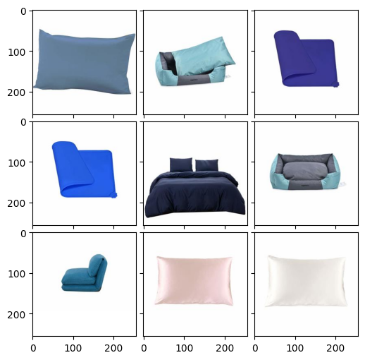

```python
image_search.search("blue pillow")
```

##### Query for more neighbors than were used to build the ann neighbors graph (default 30)

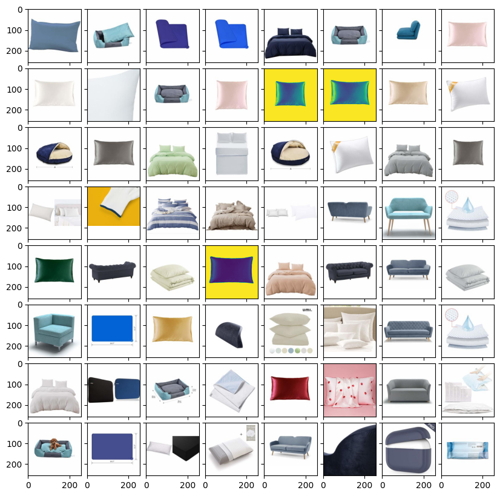

```python
image_search.search("blue pillow", 64)
```

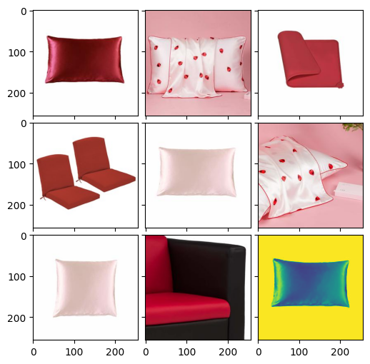

```python
image_search.search("red pillow")
```

##### Query with 2 semantic "groups" (/themes) as the input text to encode (colorful/pillow)

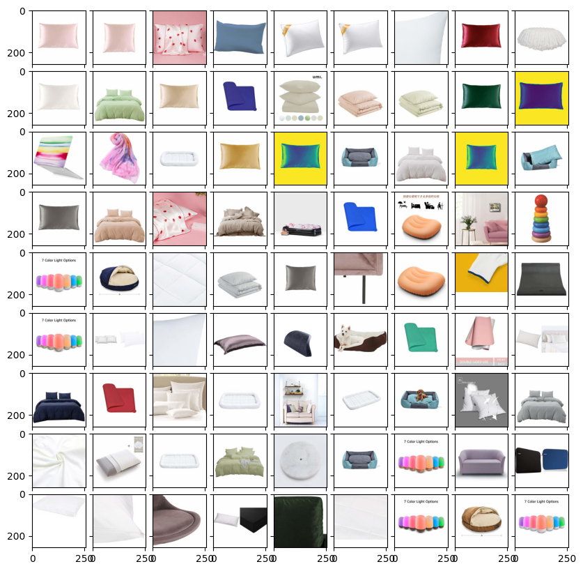

```python
image_search.search("colourful and fluffy pillow", 81)
```

Widzimy, że mieszają się obiekty "colourful" (tęczowe zabawki) i "fluffy/pillows".

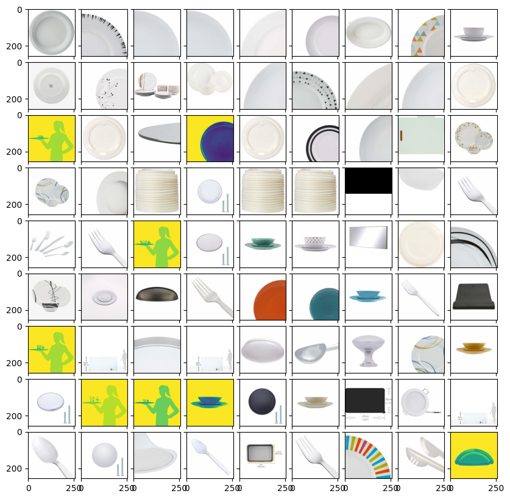

```python
image_search.search("plate", 81)
```

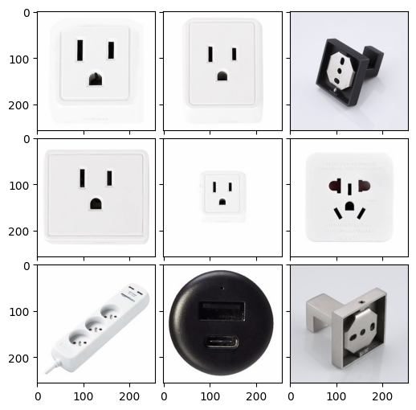

```python
image_search.search("socket")
```

All these sockets look very surprised :o

// skomentuj tutaj

Model SentenceTransformera wytrenowałam dla 10 000 zdjęć. To dość mało. Rozpoznawanie rzeczowników działa bez zarzutów, ale to dlatego, wyszukiwane rzeczowniki (pillow, socket, itp.) są w zasadzie bezprośrednio z domenty zbioru uczącego (opisy tekstów zawierają te słowa jako słowa kluczowe). Query dla takich wyrażeń jest więc w zasadzie jak testowanie klasyfikatora na zbiorze treningowym. To samo dotyczy przymiotników opisujących oczywiste i wyraźne cechy przedmiotów, typu kolor red - jest to pewnie słowo kluczowe w opisie takiego obrazka w zbiorze treningowym. Supervisorowi opisującemu zdjęcia na pewno ten czerwony rzucił się w oczy, opisał go pewnie za każdym razem (w przeciwieństwie do np. słowa fluffy, które nie wydaje się aż tak oczywiste). By prawdziwie ocenić tę wyszukiwarkę trzeba by przetestować wyrażenia 1. złożone, 2. z nieoczywistymi określeniami/nazwami przedmiotów - by przetestować skuteczność encodingu i embeddingu wyrażeń w sentence transformerze. Niestety nie mogłam tego przetestować przy tak małej użytej przeze mnie próbce 10 tys. zdjęć. Jeśli chodzi o działanie ANN, to spisuje się fajnie - search jest szybki, a budowa grafu też przebiegła szybko. Zadanie ciekawe, bo pozwala zobaczyć praktycznne korzyści ze stosowania ann.

## Zadanie dodatkowe (3 punkty)

Zapoznaj się z algorytmem [Condensed Nearest Neighbors](https://en.wikipedia.org/wiki/K-nearest_neighbors_algorithm#Condensed_Nearest_Neighbor_for_data_reduction) . Jest to algorytm typu **training set reduction**, który zmniejsza rozmiar zbioru treningowego do klasyfikacji, usuwając z niego "trywialne" próbki. Idea jest tutaj taka, że znaczenie mają zasadniczo tylko przykłady blisko granicy decyzyjnej, a te daleko od niej są oczywiste i można by tam ograniczyć liczbę próbek, przyspieszając algorytmy najbliższych sąsiadów.

Zaimplementuj algorytm Condensed Nearest Neighbors w postaci klasy kompatybilnej ze Scikit-learn, z metodami `.fit()` oraz `.transform()`. Wejściem powinny być macierz X oraz wektor y, a wyjściem zredukowane macierze, ograniczone tylko do interesujących próbek. Niestety ten algorytm jest czuły na kolejność przetwarzania próbek, dlatego ma element losowy - zaimplementuj argument `random_state` w konstruktorze i go użyj do przemieszania losowo zbioru (mogą się przydać generatory losowe z Numpy'a). Dodatkowo konstruktor powinien przyjmować argument `metric` (analogicznie do `KNeighborsClassifier`) i wykorzystywać daną metrykę jako sposób pomiaru odległości.

Przetestuj algorytm na obu zbiorach używanych w tym laboratorium:

1. Sprawdź, o ile próbek udało się zredukować zbiory treningowe.
2. Porównaj szybkość treningu, szybkość predykcji oraz jakość wyników. Zmierz też czas wykonywania samego algorytmu Condensed Nearest Neighbors.
3. Skomentuj, czy twoim zdaniem warto korzystać z takiego rozwiązania.

Przydatne źródła:

- [dykusja na DataScience Stack Exchange](https://datascience.stackexchange.com/questions/47097/proper-understanding-of-condensed-nearest-neighbor)
- [prezentacja University of Leicester o kNN i CNN](http://www.math.le.ac.uk/people/ag153/homepage/KNN/OliverKNN_Presentation.pdf)

Dla zainteresowanych polecam artykuły naukowe:

Hart, Peter. *"The condensed nearest neighbor rule (corresp.)."* IEEE transactions on information theory 14.3 (1968): 515-516. [link](https://citeseerx.ist.psu.edu/document?repid=rep1&type=pdf&doi=7c3771fd6829630cf450af853df728ecd8da4ab2)

Angiulli, Fabrizio. *"Fast condensed nearest neighbor rule."* Proceedings of the 22nd international conference on Machine learning. 2005. [link](https://icml.cc/Conferences/2005/proceedings/papers/004_Fast_Angiulli.pdf)

```python
import warnings


# To ignore some annoying warnings
warnings.simplefilter(action="ignore", category=(FutureWarning, UserWarning))
```

```python
# Common usage func
def get_data_split(
    df: pd.DataFrame, y: pd.Series
) -> tuple([pd.DataFrame, pd.DataFrame, pd.Series, pd.Series]):
    return train_test_split(df, y, test_size=0.2, random_state=0, stratify=y)
```

```python
from sklearn.neighbors import KNeighborsClassifier
import numpy as np


class CondensedNearestNeighbor:
    def __init__(
        self,
        *,
        n_neighbors=1,
        random_state=0,
        metric="euclidean",
        n_jobs=-1,
    ):
        self.n_neighbors = n_neighbors
        self.random_state = random_state
        self.metric = metric
        self.n_jobs = n_jobs
        self.iters = []
        self.grabbag = []

    def update_iter_stats(self, it, len_idxs):
        self.iters.append(it)
        self.grabbag.append(len_idxs)

    def fit(self, X, y):
        self.knn = KNeighborsClassifier(
            n_neighbors=self.n_neighbors,
            metric=self.metric,
            n_jobs=self.n_jobs,
        )
        self.rng = np.random.default_rng(self.random_state)
        self.original_samples_no = X.shape[0]
        return self

    def transform(self, X, y) -> (pd.DataFrame, pd.Series):
        # Store bin
        X_store = pd.DataFrame()
        y_store = pd.Series()

        # Keep the original dfs safe
        X = X.copy(deep=True)
        y = y.copy(deep=True)

        # Random_state in here
        idxs = np.array(X.index)
        self.rng.shuffle(idxs)
        self.update_iter_stats(0, len(idxs))

        # Samples to remove
        grabbag_idx = []

        # First sample always goes to store bin
        X_store = X_store._append(X.loc[idxs[0]].copy(deep=True))
        y_store = pd.concat(
            [y_store, pd.Series(y.loc[idxs[0]].copy(), index=[idxs[0]])]
        )

        # First pass through original sample set (training data)
        for i, loc_idx in enumerate(idxs):
            # We've already handled 1st sample
            if i == 0:
                continue

            x_sample = X.loc[loc_idx].values.reshape(1, -1)
            y_true = y.loc[loc_idx]

            self.knn.fit(X_store, y_store)
            y_pred = self.knn.predict(x_sample)

            # Misclassified case
            if y_pred != y_true:
                # Transfer to store bin
                X_store = X_store._append(X.loc[loc_idx].copy(deep=True))
                y_store = pd.concat(
                    [
                        y_store,
                        pd.Series(y.loc[loc_idx].copy(), index=[loc_idx]),
                    ]
                )

                X = X.drop(loc_idx)
                y = y.drop(loc_idx)

                grabbag_idx.append(i)

        idxs = np.delete(idxs, grabbag_idx)

        # Stop
        # 1st case: when the grabbag is exhausted
        # 2nd case: once one complete pass through grabbag
        # has been made without any sample removal
        one_clear_pass = False
        it = 0
        while len(idxs) > 0 and not one_clear_pass:
            self.rng.shuffle(idxs)
            grabbag_idx = []

            one_clear_pass = True
            for i, loc_idx in enumerate(idxs):
                x_sample = X.loc[loc_idx].values.reshape(1, -1)
                y_true = y.loc[loc_idx]

                self.knn.fit(X_store, y_store)
                y_pred = self.knn.predict(x_sample)

                # Misclassified case
                if y_pred != y_true:
                    # Transfer to store bin
                    X_store = X_store._append(X.loc[loc_idx].copy(deep=True))
                    y_store = pd.concat(
                        [
                            y_store,
                            pd.Series(y.loc[loc_idx].copy(), index=[loc_idx]),
                        ]
                    )

                    X = X.drop(loc_idx)
                    y = y.drop(loc_idx)

                    one_clear_pass = False
                    grabbag_idx.append(i)

            idxs = np.delete(idxs, grabbag_idx)
            self.update_iter_stats(it := it + 1, len(idxs))

        return X_store, y_store
```

Called like:

```python
from termcolor import colored
from sklearn.metrics import jaccard_score
from sklearn.metrics import roc_auc_score
from sklearn.metrics import f1_score
from sklearn.neighbors import KNeighborsClassifier


def benchmark_knn_cnn(
    knn, cnn, X_train, X_test, y_train, y_test, auroc=False
) -> None:
    # Training
    # KNN 1
    start_time = time()
    knn.fit(X_train, y_train)
    end_time = time()

    knn_fit_time = end_time - start_time

    # (CNN) KNN 2
    cnn.fit(X_train, y_train)
    # All the magic happens in .transform()
    start_time = time()
    X_reduced, y_reduced = cnn.transform(X_train, y_train)
    end_time = time()

    cnn_transform_time = end_time - start_time

    # Now, as we've got reduced X and y
    # the real CNN classifier benchmark begins
    # CNN training
    start_time = time()
    cnn.fit(X_reduced, y_reduced)
    cnn.knn.fit(X_reduced, y_reduced)
    end_time = time()

    cnn_fit_time = end_time - start_time

    # Prediction
    # KNN
    start_time = time()
    y_pred_knn_test = knn.predict(X_test)
    end_time = time()

    knn_predict_time = end_time - start_time

    # CNN
    start_time = time()
    y_pred_cnn_test = cnn.knn.predict(X_test)
    end_time = time()

    cnn_predict_test_time = end_time - start_time

    # CNN safety check - prediction of training data
    start_time = time()
    y_pred_cnn_train = cnn.knn.predict(X_train)
    end_time = time()

    cnn_predict_train_time = end_time - start_time

    f1_cnn_train = f1_score(y_train, y_pred_cnn_train, average="macro")

    print(colored(f"{'-'*20} CNN SAFETY CHECK {'-'*20}\n", "blue"))
    print(
        f"CNN prediction on training data is the same as on \
    original KNN before sample reduction"
    )
    print(
        f"y_pred_cnn_train == y_train).all(): \
    {(y_pred_cnn_train == y_train).all()}"
    )
    print(f"CNN score on training dataset: {cnn.knn.score(X_train, y_train)}")
    print(
        f"CNN score on reduced dim dataset: {cnn.knn.score(X_reduced, y_reduced)}"
    )
    print(f"CNN f1 score for training dataset: {f1_cnn_train}")
    print()

    f1_knn = f1_score(y_test, y_pred_knn_test, average="macro")
    f1_cnn = f1_score(y_test, y_pred_cnn_test, average="macro")

    print(colored(f"{'-'*20} TIMES {'-'*20}\n", "blue"))
    print(f"KNN fit time: {knn_fit_time:.2f}")
    print(f"CNN fit time: {cnn_fit_time:.2f}")
    print(f"CNN actual training (transform) time: {cnn_transform_time:.2f}")
    print()
    print(f"KNN prediction time: {knn_predict_time:.2f}")
    print(f"CNN prediction time: {cnn_predict_test_time:.2f}")
    print()

    print(colored(f"{'-'*20} ACCURACY {'-'*20}\n", "blue"))
    print(f"KNN F1 score: {100 * f1_knn:.2f}%")
    print(f"CNN F1: {100 * f1_cnn:.2f}%")

    # Only for binary classes datasets
    if auroc:
        # KNN
        start_time = time()
        knn_y_pred_proba = knn.predict_proba(X_test)
        end_time = time()

        knn_predict_proba_time = end_time - start_time

        # CNN
        start_time = time()
        cnn_y_pred_proba = cnn.knn.predict_proba(X_test)
        end_time = time()

        cnn_predict_proba_time = end_time - start_time

        knn_auroc = roc_auc_score(y_test, knn_y_pred_proba[:, 1])
        cnn_auroc = roc_auc_score(y_test, cnn_y_pred_proba[:, 1])

        print(colored(f"{'-'*20} AUROC {'-'*20}\n", "blue"))
        print(f"KNN predict_proba time: {knn_predict_proba_time}")
        print(f"KNN AUROC: {100 * knn_auroc:.2f}%")
        print(f"CNN predict_proba time: {cnn_predict_proba_time}")
        print(f"CNN AUROC: {100 * cnn_auroc:.2f}%")

    return X_reduced, y_reduced
```

### Codon data

```python
from sklearn.model_selection import train_test_split


df, y = load_prepare_codon_data()
X_train, X_test, y_train, y_test = get_data_split(df, y)
```

##### Original CNN with 1 nn

```python
cnn = CondensedNearestNeighbor()
knn = KNeighborsClassifier(n_neighbors=1, n_jobs=-1)
```

##### Benchmark

```python
X_reduced, y_reduced = benchmark_knn_cnn(
    knn, cnn, X_train, X_test, y_train, y_test
)
```

```
-------------------- CNN SAFETY CHECK --------------------

CNN prediction on training data is the same as on     original KNN before sample reduction
y_pred_cnn_train == y_train).all():     True
CNN score on training dataset: 1.0
CNN score on reduced dim dataset: 1.0
CNN f1 score for training dataset: 1.0

-------------------- TIMES --------------------

KNN fit time: 0.01
CNN fit time: 0.00
CNN actual training (transform) time: 115.81

KNN prediction time: 0.14
CNN prediction time: 0.10

-------------------- ACCURACY --------------------

KNN F1 score: 89.16%
CNN F1: 86.13%
```

##### Sampleset reduction

```
Samples before: 10406, samples after: 1296
% of sampleset reduction: 87.55
```

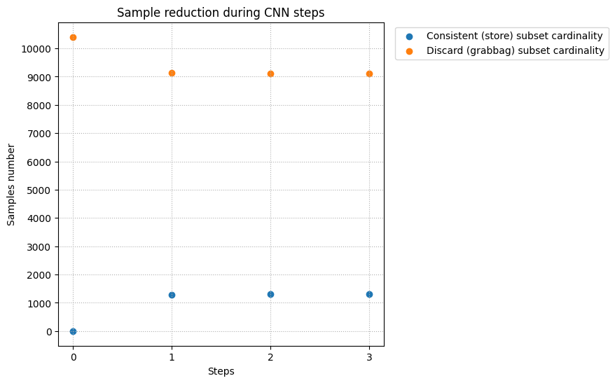

```python
X_reduced_codon = X_reduced
y_reduced_codon = y_reduced

cnn_codon_iters = cnn.iters.copy()
cnn_codon_grabbag = cnn.grabbag.copy()

cnn_codon_added = [X_train.shape[0] - g + 1 for g in cnn_codon_grabbag]

print(
    f"Samples before: {X_train.shape[0]}, samples after: {X_reduced_codon.shape[0]}"
)
print(
    f"% of sampleset reduction: {((1-X_reduced_codon.shape[0]/X_train.shape[0])*100):.2f}"
)

fig, ax = plt.subplots(1, 1, sharey=True, figsize=(6, 6))
ax.scatter(
    cnn_codon_iters,
    cnn_codon_added,
    label="Consistent (store) subset cardinality",
)
ax.scatter(
    cnn_codon_iters,
    cnn_codon_grabbag,
    label="Discard (grabbag) subset cardinality",
)
ax.set_xlabel("Steps")
ax.set_ylabel("Samples number")
ax.set_yticks(np.arange(0, X_train.shape[0], step=1000))
ax.set_xticks(np.arange(0, 4, step=1))
ax.grid(which="major", linestyle=":")
ax.legend(bbox_to_anchor=(1.02, 1), loc=2)
ax.set_title("Sample reduction during CNN steps")
plt.show()
```

### Mol hiv data

```python
X_train, X_valid, X_test, y_train, y_valid, y_test = load_prepare_molhiv_data()
X = np.concatenate((X_train, X_valid), axis=0)
y = np.concatenate((y_train, y_valid), axis=0)
X = pd.DataFrame(X)
y = pd.Series(y)
```

```python
cnn_molhiv = CondensedNearestNeighbor()
knn_molhiv = KNeighborsClassifier(n_neighbors=1, n_jobs=-1)
```

##### Benchmark

```python
X_reduced_molhiv, y_reduced_molhiv = benchmark_knn_cnn(
    knn_molhiv, cnn_molhiv, X, X_test, y, y_test
)
```

```
-------------------- CNN SAFETY CHECK --------------------

CNN prediction on training data is the same as on     original KNN before sample reduction
y_pred_cnn_train == y_train).all():     False
CNN score on training dataset: 0.9996217647376668
CNN score on reduced dim dataset: 0.9972783825816485
CNN f1 score for training dataset: 0.9972403610798654

-------------------- TIMES --------------------

KNN fit time: 0.07
CNN fit time: 0.01
CNN actual training (transform) time: 6115.80

KNN prediction time: 6.79
CNN prediction time: 1.15

-------------------- ACCURACY --------------------

KNN F1 score: 61.41%
CNN F1: 55.68%
```

##### AUROC

```python
# KNN
start_time = time()
knn_y_pred_proba = knn_molhiv.predict_proba(X_test)
end_time = time()

knn_predict_proba_time = end_time - start_time

# CNN
start_time = time()
cnn_y_pred_proba = cnn_molhiv.knn.predict_proba(X_test)
end_time = time()

cnn_predict_proba_time = end_time - start_time


knn_auroc = roc_auc_score(y_test, knn_y_pred_proba[:, 1])
cnn_auroc = roc_auc_score(y_test, cnn_y_pred_proba[:, 1])

print(colored(f"{'-'*20} AUROC {'-'*20}\n", "blue"))
print(f"KNN predict_proba time: {knn_predict_proba_time:.2f}")
print(f"KNN AUROC: {100 * knn_auroc:.2f}%")
print(f"CNN predict_proba time: {cnn_predict_proba_time:.2f}")
print(f"CNN AUROC: {100 * cnn_auroc:.2f}%")
```

```
-------------------- AUROC --------------------

KNN predict_proba time: 4.98
KNN AUROC: 60.24%
CNN predict_proba time: 0.78
CNN AUROC: 60.06%
```

##### Sampleset reduction

```
Samples before: 37014, samples after: 5144
% of sampleset reduction: 86.10
```

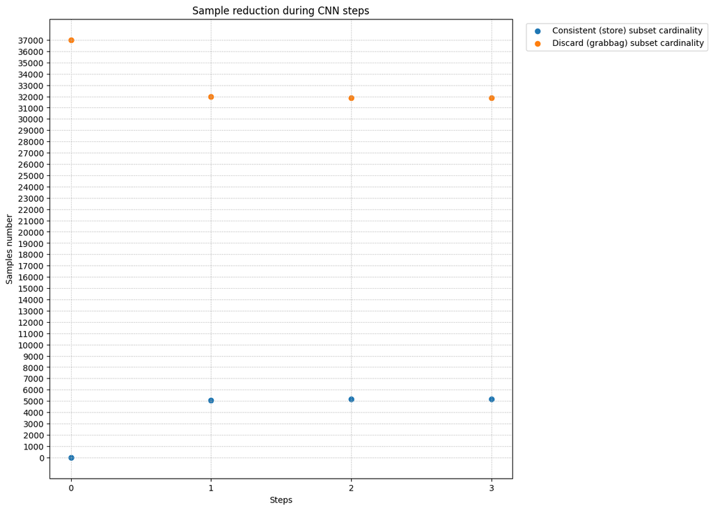

```python
cnn_molhiv_iters = cnn_molhiv.iters.copy()
cnn_molhiv_grabbag = cnn_molhiv.grabbag.copy()

samples_before = X.shape[0]
samples_after = X_reduced_molhiv.shape[0]

cnn_molhiv_added = [samples_before - g + 1 for g in cnn_molhiv_grabbag]

print(f"Samples before: {samples_before}, samples after: {samples_after}")
print(
    f"% of sampleset reduction: {((1-samples_after/samples_before)*100):.2f}"
)

fig, ax = plt.subplots(1, 1, sharey=True, figsize=(10, 10))
ax.scatter(
    cnn_molhiv_iters,
    cnn_molhiv_added,
    label="Consistent (store) subset cardinality",
)
ax.scatter(
    cnn_molhiv_iters,
    cnn_molhiv_grabbag,
    label="Discard (grabbag) subset cardinality",
)
ax.set_xlabel("Steps")
ax.set_ylabel("Samples number")
ax.set_yticks(np.arange(0, samples_before, step=1000))
ax.set_xticks(np.arange(0, 4, step=1))
ax.grid(which="major", linestyle=":")
ax.legend(bbox_to_anchor=(1.02, 1), loc=2)
ax.set_title("Sample reduction during CNN steps")
plt.show()
```

#### Task Summary and Conclusions

Budowa consistent subset w takim naiwnym wydaniu implementacyjnym jest kompletnie nieporęczna. O ile w 1. przykładzie czas treningu cnn 2 min. był do zniesienia, to nie zauważono tam wyraźnych korzyści z tej metody (prawie takie same czasy predykcji). W 2. przypadku czas treningu cnn był nie do zniesienia, chociać przynajmniej można było zobaczyć miły wynik w postaci ww. różnic w czasach predykcji. Całkiem możliwe, że dla innej liczby sąsiadów miary jakości modelu okazałyby się lepsze, ale nie ma co gdybać. Prawdopodobnie liczył się tak długo z powodu dużej l. wymiarów.

Trzeba przyznać tej metodzie 1 rację - ograniczenie liczby próbek jest rzeczywiście bardzo duże, w obu przypadkach po ok. 86%. Pytanie jednak, jakie to ma znaczenie - próbki te trzeba było najpierw zebrać (koszta), by móc uznać, że są zbędne. Widać tutaj jednak potencjał w przypadku użycia algorytmów o ZO liczonej głównie względem l. próbek n.

Ciekawym jest, że, jak wynika z wykresów, obu programom potrzeba było 4 kroków (0+3) do osiągnięcia "zbieżności" i że właściwie cały consistent subset został zbudowany już w 1. iteracji.